# A01281942

## Reading in the data

Here we read in data exported from the mongoDB database running on the AWS server. Outcomes contains only the itemID, categoryID/Name, and final selling price. forSale contains any features I thought might be of use to a machine learning algorithm. This includes things like the item’s title string as well as location.

```r
outcomes = read.csv("completedItems_2.csv",header=TRUE)
forSale = read.csv("forSale_2.csv",header=TRUE)
head(outcomes)
```

```
##           X_id categoryId        categoryName sellingPrice
## 1 112185507879     139971 Video Game Consoles       349.99
## 2 122202585486     139971 Video Game Consoles       305.00
## 3 291926308477     139971 Video Game Consoles       200.98
## 4 262695233466     139971 Video Game Consoles       280.00
## 5 142163675662     139971 Video Game Consoles       220.00
## 6 262695805629     139971 Video Game Consoles       250.00
```

```r
head(forSale)
```

```
##           X_id
## 1 172388678529
## 2 122194533957
## 3 282229141811
## 4 282233993583
## 5 162252708291
## 6 131981426207
##                                                                           title
## 1                  NEW PLAYSTATION 4 LIMITED EDITION TACO BELL GOLD CONSOLE PS4
## 2 SONY PLAYSTATION 4 (CUH-1215A) 500GB DESTINY THE TAKEN KING LIMITED EDITION
## 3                                         SONY PLAYSTATION 4 SYSTEM  500 GIG HD
## 4                                   SONY PLAYSTATION 4 500 GB JET BLACK CONSOLE
## 5                    UNCHARTED 4: A THIEF'S END (SONY PLAYSTATION 4 SLIM, 2016)
## 6                                                            SONY PLAYSTATION 4
##   currentPrice shippingCost calculateShipping totalPrice
```

[output cut: 34 more lines]

Above is shown an overview of every feature collected from the eBay API in the forSale dataframe. A few confusing one’s will be noted for the purposes of this presentation.

- **calculateShipping** is a boolean that tells me whether the eBay API returned the shipping price for an item, or if this item needs to be queried with a separate API call to get it’s shipping price. The items with true will probably be imputed with an average of all shipping prices.
- **dateQueried** is the date my algorithm found the item on eBay.
- **endDate** is when the item was no longer for sale (I think I will turn these into categoric variables to see if day of the week is an important variable to price prediction)
- **bidCount** is how many bids have been placed on this item when the my algorithm found it on eBay.
- **listingType** describes whether the item is a FixedPrice item or an item for Auction.
- **conditionId** is a condition code used by eBay to desribe an item’s condition, 1000 is new, 3000, is used, 1500 is new with conditions attached to the item.
- **timeLeft** specifies how much longer this item is for sale.

## Pre-processing

I will perform the imputation of shipping costs now. First we change the -1 values to NA’s, and then impute NA’s with the average shipping cost for non NA items.

```r
forSale$shippingCost[forSale$calculateShipping == "true"] = NA
forSale$shippingCost = with (forSale,impute(shippingCost,mean))
forSale$bidCount     = with(forSale, impute(bidCount,mean))
forSale$bidCount = as.numeric(forSale$bidCount)
```

Calculating imputed totalPrice and removing sold items that aren’t video game consoles.

```r
forSale$totalPrice = forSale$currentPrice + forSale$shippingCost
forSale$totalPrice = as.numeric(forSale$totalPrice)
outcomes = outcomes[outcomes$categoryName == "Video Game Consoles",]
```

### Dates

Here I’m converting date strings to actual R dates.

```r
dates = as.Date(forSale$endDate)
forSale$dayOfWeek = as.factor(weekdays(dates))
```

### Outliers

We can use R’s built in boxplot code to detect and remove outliers from the dataset.

```r
outliers = boxplot.stats(forSale$totalPrice)$out
forSale = forSale[!forSale$totalPrice %in% outliers,]
forSale = forSale[(forSale$totalPrice > 100),]
```

## Summary

Here we summarize the data to see if anything stands out as interesting in the data for further analysis or visualization.

### forSale Summary

It looks like surprisingly there are a higher number of Playstation 4’s with the title “SONY PLAYSTATION 4 BASIC SET 500 GB BLACK CONSOLE” and “SONY PLAYSTATION 4 (LATEST MODEL)- 500 GB BLACK CONSOLE” in the title. This may be due to the fact that many people are buying and relisting with the same title, similar to my software. We also print out the SD for all playstation 4’s in order to get a better idea of how variable the prices are.

```r
summary(forSale)
```

```
##
##  739 values imputed to 10.05239
```

```
##       X_id
##  Min.   :1.120e+11
##  1st Qu.:1.623e+11
##  Median :2.223e+11
##  Mean   :2.271e+11
##  3rd Qu.:2.822e+11
##  Max.   :4.012e+11
##
##                                                                               title
##  SONY PLAYSTATION 4 BASIC SET 500 GB BLACK CONSOLE                               : 212
##  SONY PLAYSTATION 4 (LATEST MODEL)- 500 GB BLACK CONSOLE                         :  67
##  SONY PLAYSTATION 4 500 GB BLACK CONSOLE                                         :  58
##  SONY PLAYSTATION 4 CALL OF DUTY: BLACK OPS III - STANDARD EDITION 500 GB JET... :  42
##  PLAYSTATION 4                                                                   :  24
##  SONY PLAYSTATION 4 CALL OF DUTY: BLACK OPS III - STANDARD EDITION 500 GB JET BL…:  20
##  (Other)                                                                         :1216
##   currentPrice    shippingCost   calculateShipping   totalPrice
##  Min.   : 80.0   Min.   : 0.00   false:900         Min.   :102.0
##  1st Qu.:177.5   1st Qu.: 0.00   true :739         1st Qu.:187.5
##  Median :202.5   Median :10.05                     Median :215.5
##  Mean   :225.8   Mean   :10.21                     Mean   :236.0
##  3rd Qu.:255.0   3rd Qu.:12.95                     3rd Qu.:269.0
##  Max.   :469.9   Max.   :50.00                     Max.   :469.9
##
##                    dateQueried                      endDate
##                          :739   2016-11-02T17:06:29.000Z:   2
##  2016-10-29T07:30:02.423Z:  1   2016-11-04T01:00:08.000Z:   2
##  2016-10-29T07:30:03.615Z:  1   2016-11-12T03:00:07.000Z:   2
##  2016-10-29T07:30:03.620Z:  1   2016-11-14T16:27:11.000Z:   2
##  2016-10-29T07:30:03.623Z:  1   2016-11-15T15:30:23.000Z:   2
##  2016-10-29T07:30:03.629Z:  1   2016-11-22T00:59:57.000Z:   2
##  (Other)                 :895   (Other)                 :1627
##                location       country        bidCount
##  USA               :  38   US     :1585   Min.   : 0.00
##  Canada            :  28   CA     :  28   1st Qu.: 0.00
##  Columbus,OH,USA   :  23   GB     :   5   Median : 8.00
##  Miami,FL,USA      :  21   KR     :   5   Mean   :11.36
##  Los Angeles,CA,USA:  20   JP     :   4   3rd Qu.:12.00
##  New York,NY,USA   :  18   RU     :   3   Max.   :82.00
##  (Other)           :1491   (Other):   9
```

[output cut: 17 more lines]

```
##  {"milliseconds":0,"seconds":14,"minutes":28,"hours":18,"days":0,"months":0,"years":0}:   3
##  {"milliseconds":0,"seconds":0,"minutes":43,"hours":18,"days":0,"months":0,"years":0} :   2
##  {"milliseconds":0,"seconds":10,"minutes":4,"hours":16,"days":0,"months":0,"years":0} :   2
##  {"milliseconds":0,"seconds":13,"minutes":28,"hours":18,"days":0,"months":0,"years":0}:   2
##  {"milliseconds":0,"seconds":16,"minutes":33,"hours":20,"days":0,"months":0,"years":0}:   2
##  {"milliseconds":0,"seconds":22,"minutes":28,"hours":10,"days":0,"months":0,"years":0}:   2
##  (Other)                                                                              :1626
##      dayOfWeek
##  Friday   :225
##  Monday   :300
##  Saturday :223
##  Sunday   :266
##  Thursday :203
##  Tuesday  :248
##  Wednesday:174
```

```r
sd(forSale$totalPrice)
```

```
## [1] 68.25486
```

### Initial Questions

- Does a higher bidCount the day before the end date result in a higher price?
- Does buyItNow effect price?
- Does the text in the item title effect price? (appears to be significant after totalCost)
- Does day of the week effect price?

### Outcomes Summary

It appears that the SD’s of the two datasets are similar, which gives me some comfort in the data gathering methods.

```r
summary(outcomes)
```

```
##       X_id             categoryId                            categoryName
##  Min.   :1.121e+11   Min.   :139971   Video Game Consoles          :7797
##  1st Qu.:1.623e+11   1st Qu.:139971   Cell Phones & Smartphones    :   0
##  Median :2.321e+11   Median :139971   Consoles de jeux vidéo       :   0
##  Mean   :2.297e+11   Mean   :139971   Console Systems              :   0
##  3rd Qu.:2.822e+11   3rd Qu.:139971   DJ Controllers               :   0
##  Max.   :4.012e+11   Max.   :139971   Faceplates, Decals & Stickers:   0
##                                       (Other)                      :   0
##   sellingPrice
##  Min.   :120.0
##  1st Qu.:224.9
##  Median :247.5
##  Mean   :265.0
##  3rd Qu.:285.0
##  Max.   :592.0
##
```

```r
sd(outcomes$sellingPrice)
```

```
## [1] 70.30095
```

## Visualization

I’d first like to see the histogram of these items and see just how variable their prices are.

### Histogram of Price Counts for Sold Playstation4s

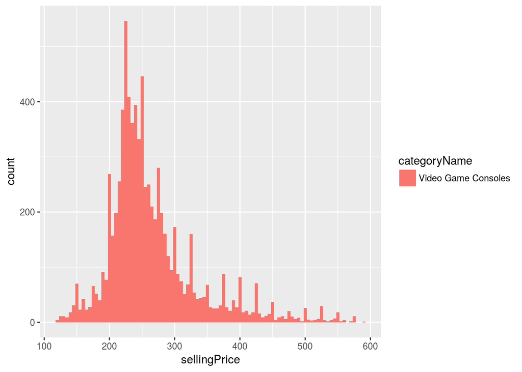

```r
library(ggplot2)
ggplot(outcomes, aes(sellingPrice, fill = categoryName)) +
  geom_histogram(binwidth = 5)
```

###Histogram of Price Counts for Playstation4s currently for sale

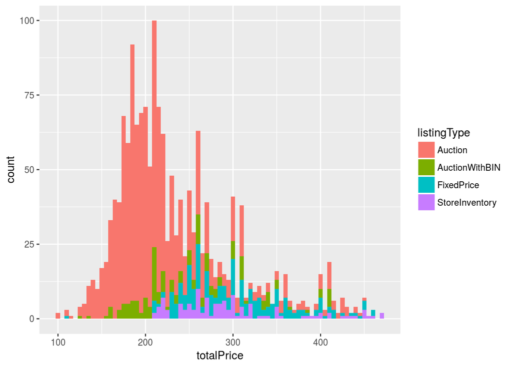

```r
ggplot(forSale, aes(totalPrice, fill = listingType)) +
  geom_histogram(binwidth = 5)
```

These data both appear to be positively skewed.

### Plotting the location of sold Playstation4s

The map plot shows a high number of Playstation 4’s are sold in the North East of the US and around the Los Angeles area. This is probably simple due to the higher populations in these areas.

[figure not shown]

```r
library(ggmap)
map1 = ggmap(get_map(location = "United States",zoom=4))+geom_point(data=locations, aes(x=lon,y=lat),color="orange")
map1
```

## Gluing outcome and forSale dataset

Now we merge the outcome into the forSale dataset to train, CV, and test machine learning algorithms against it.

```r
fullDataset <- merge(forSale,outcomes,by="X_id")
summary(fullDataset)
```

```
##
##  516 values imputed to 10.05239
```

```
##       X_id
##  Min.   :1.122e+11
##  1st Qu.:1.623e+11
##  Median :2.223e+11
##  Mean   :2.292e+11
##  3rd Qu.:2.823e+11
##  Max.   :4.012e+11
##
##                                                                               title
##  SONY PLAYSTATION 4 BASIC SET 500 GB BLACK CONSOLE                               :172
##  SONY PLAYSTATION 4 (LATEST MODEL)- 500 GB BLACK CONSOLE                         : 44
##  SONY PLAYSTATION 4 500 GB BLACK CONSOLE                                         : 38
##  SONY PLAYSTATION 4 CALL OF DUTY: BLACK OPS III - STANDARD EDITION 500 GB JET... : 31
##  SONY PLAYSTATION 4 CALL OF DUTY: BLACK OPS III - STANDARD EDITION 500 GB JET BL…: 17
##  PLAYSTATION 4                                                                   : 16
##  (Other)                                                                         :779
##   currentPrice    shippingCost   calculateShipping   totalPrice
##  Min.   : 80.0   Min.   : 0.00   false:581         Min.   :102.0
##  1st Qu.:170.0   1st Qu.:10.05   true :516         1st Qu.:181.1
##  Median :192.0   Median :10.05                     Median :201.6
##  Mean   :202.9   Mean   :10.84                     Mean   :213.7
##  3rd Qu.:219.5   3rd Qu.:14.99                     3rd Qu.:230.0
##  Max.   :450.0   Max.   :50.00                     Max.   :450.0
##
##                    dateQueried                      endDate
##                          :516   2016-11-04T01:00:08.000Z:   2
##  2016-10-29T07:30:02.423Z:  1   2016-11-14T16:27:11.000Z:   2
##  2016-10-29T07:30:03.620Z:  1   2016-11-15T15:30:23.000Z:   2
##  2016-10-29T07:30:03.623Z:  1   2016-11-22T00:59:57.000Z:   2
##  2016-10-29T07:30:03.629Z:  1   2016-10-29T15:18:15.000Z:   1
##  2016-10-29T07:30:04.831Z:  1   2016-10-29T16:47:03.000Z:   1
##  (Other)                 :576   (Other)                 :1087
##                location       country        bidCount
##  USA               :  23   US     :1071   Min.   : 0.00
##  Canada            :  17   CA     :  17   1st Qu.: 1.00
##  Brooklyn,NY,USA   :  14   PR     :   2   Median : 5.00
##  Boise,ID,USA      :  13   AU     :   1   Mean   :12.89
##  Columbus,OH,USA   :  13   EE     :   1   3rd Qu.:20.00
##  Los Angeles,CA,USA:  12   GB     :   1   Max.   :82.00
##  (Other)           :1005   (Other):   4
```

[output cut: 25 more lines]

```
##  Friday   :157   Min.   :139971   Video Game Consoles          :1097
##  Monday   :219   1st Qu.:139971   Cell Phones & Smartphones    :   0
##  Saturday :151   Median :139971   Consoles de jeux vidéo       :   0
##  Sunday   :190   Mean   :139971   Console Systems              :   0
##  Thursday :140   3rd Qu.:139971   DJ Controllers               :   0
##  Tuesday  :139   Max.   :139971   Faceplates, Decals & Stickers:   0
##  Wednesday:101                    (Other)                      :   0
##   sellingPrice
##  Min.   :127.5
##  1st Qu.:223.5
##  Median :243.5
##  Mean   :255.9
##  3rd Qu.:275.0
##  Max.   :545.0
##
```

## Day Of Week

```r
averagePricePerDay = with(fullDataset, tapply(sellingPrice, dayOfWeek,mean))
plotDF =aggregate(fullDataset$sellingPrice ~ fullDataset$dayOfWeek, FUN = mean)
plotDF
```

```
##   fullDataset$dayOfWeek fullDataset$sellingPrice
## 1                Friday                 251.0188
## 2                Monday                 255.1098
## 3              Saturday                 253.4496
## 4                Sunday                 261.3309
## 5              Thursday                 246.7069
## 6               Tuesday                 266.2805
## 7             Wednesday                 257.3285
```

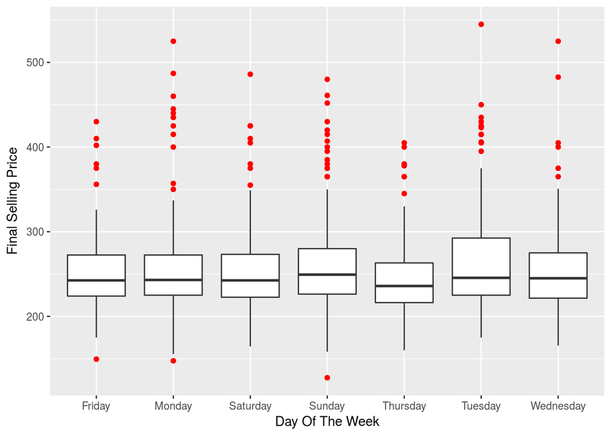

```r
ggplot(fullDataset, aes(y = sellingPrice, x = factor(dayOfWeek))) +scale_x_discrete("Day Of The Week") +
        scale_y_continuous("Final Selling Price") + geom_boxplot(outlier.color="red")
```

```r
pairwise.t.test(fullDataset$sellingPrice,
                fullDataset$dayOfWeek, alternative ="two.sided")
```

```
##
##  Pairwise comparisons using t tests with pooled SD
##
## data:  fullDataset$sellingPrice and fullDataset$dayOfWeek
##
##           Friday Monday Saturday Sunday Thursday Tuesday
## Monday    1.000  -      -        -      -        -
## Saturday  1.000  1.000  -        -      -        -
## Sunday    1.000  1.000  1.000    -      -        -
## Thursday  1.000  1.000  1.000    0.263  -        -
## Tuesday   0.263  0.878  0.705    1.000  0.043    -
## Wednesday 1.000  1.000  1.000    1.000  1.000    1.000
##
## P value adjustment method: holm
```

```r
oneway.test(sellingPrice ~ dayOfWeek, data = fullDataset)
```

```
##
##  One-way analysis of means (not assuming equal variances)
##
## data:  sellingPrice and dayOfWeek
## F = 2.1621, num df = 6.00, denom df = 450.09, p-value = 0.04555
```

## Bid Count

It doesn’t look as though the number of bids effects price that much. We do see a slightly positive correlation in regard to new items with conditions attached to them, but again, this could be due to lack of data.

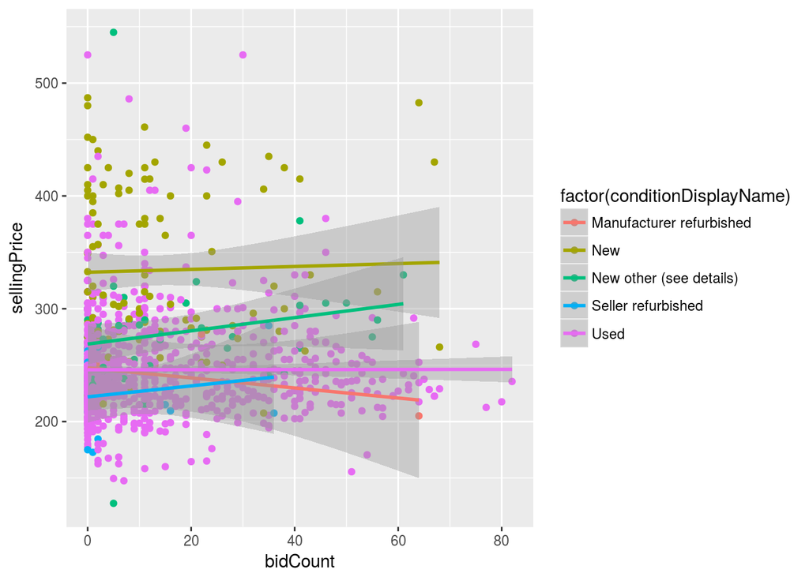

```r
p1 <- ggplot(fullDataset, aes(x = bidCount, y = sellingPrice, color = factor(conditionDisplayName))) + geom_point() + geom_smooth(method = "lm", se = TRUE)
p1
```

```r
lmOut = lm(sellingPrice ~ bidCount, data = fullDataset)
summary(lmOut)
```

```
##
## Call:
## lm(formula = sellingPrice ~ bidCount, data = fullDataset)
##
## Residuals:
##     Min      1Q  Median      3Q     Max
## -127.90  -32.58  -12.40   18.98  289.60
##
## Coefficients:
##              Estimate Std. Error t value Pr(>|t|)
## (Intercept) 255.07652    2.02825 125.762   <2e-16 ***
## bidCount      0.06546    0.09648   0.679    0.498
## ---
## Signif. codes:  0 '***' 0.001 '**' 0.01 '*' 0.05 '.' 0.1 ' ' 1
##
## Residual standard error: 53.06 on 1095 degrees of freedom
## Multiple R-squared:  0.0004202,  Adjusted R-squared:  -0.0004926
## F-statistic: 0.4604 on 1 and 1095 DF,  p-value: 0.4976
```

We also see the p-value on a linear regression as too high for statistical significance.

## Buy It Now

Does the ability to “buy it now” effect price in any way?

```r
averagePricePerBuyItNow = with(fullDataset, tapply(sellingPrice, buyItNowAvailable,mean))
plotDF = aggregate(fullDataset$sellingPrice ~ fullDataset$buyItNowAvailable, FUN = mean)
plotDF
```

```
##   fullDataset$buyItNowAvailable fullDataset$sellingPrice
## 1                         false                 254.3955
## 2                          true                 276.1234
```

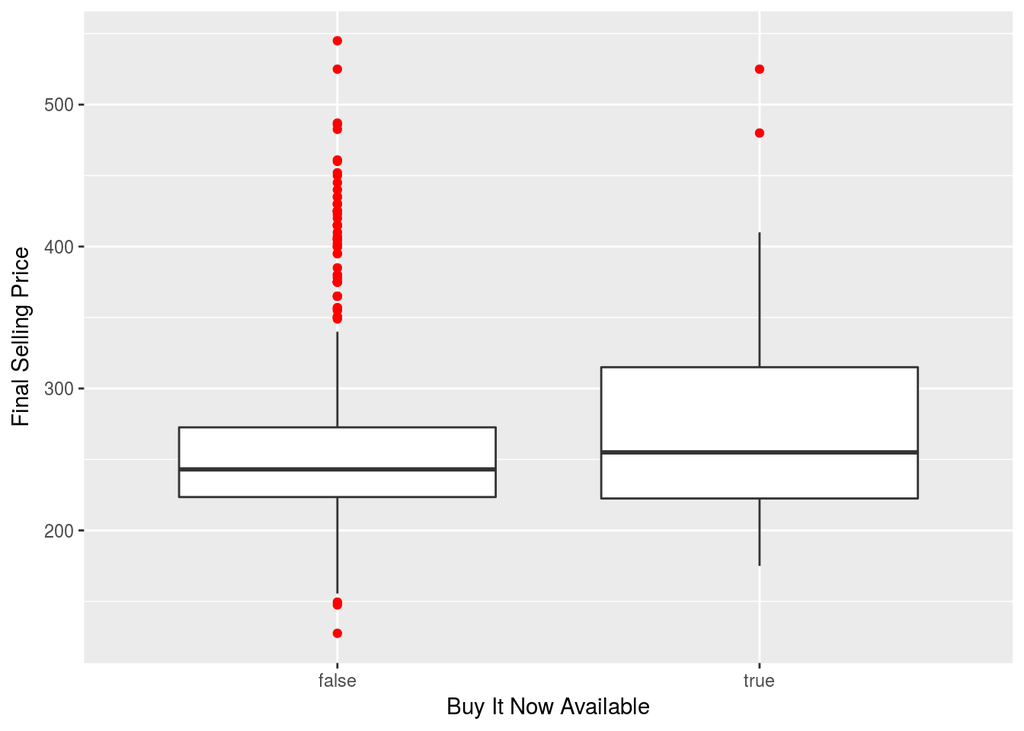

```r
ggplot(fullDataset, aes(y = sellingPrice, x = factor(buyItNowAvailable))) +scale_x_discrete("Buy It Now Available") +
        scale_y_continuous("Final Selling Price") + geom_boxplot(outlier.color="red")
```

But is this statistically significant? A pairwise t-test across the BuyItNow variable as well as a oneway ANOVA shows that it actually may be. Again, this may be due to the fact that my dataset is still relatively small though.

```r
pairwise.t.test(fullDataset$sellingPrice,
                fullDataset$buyItNowAvailable, alternative ="two.sided")
```

```
##
##  Pairwise comparisons using t tests with pooled SD
##
## data:  fullDataset$sellingPrice and fullDataset$buyItNowAvailable
##
##      false
## true 0.00051
##
## P value adjustment method: holm
```

```r
oneway.test(sellingPrice ~ buyItNowAvailable, data = fullDataset)
```

```
##
##  One-way analysis of means (not assuming equal variances)
##
## data:  sellingPrice and buyItNowAvailable
## F = 7.388, num df = 1.000, denom df = 82.544, p-value = 0.008
```

## Title Analysis

Here we analyze the titles used in listings. This is done by taking relatively sparse terms using tf-idf and looking to see if any of these terms stand out in relation to price. Another question could be, does using a similar title to other listings lead to a higher selling price?

```r
library(tm)
```

```r
library(wordcloud)
text = Corpus(VectorSource(fullDataset$title))
text = tm_map(text,removePunctuation)
text = tm_map(text,content_transformer(tolower))
text = tm_map(text,removeWords,stopwords("english"))
# for(i in seq(text)){
#         text[[i]] = gsub("playstation4","playstation4",text[[i]])
#         text[[i]] = gsub("playstation 4","playstation4",text[[i]])
#         text[[i]] = gsub("playstation","playstation4",text[[i]])
# }
# text <- tm_map(text, stemDocument)
text <- tm_map(text, stripWhitespace)
# text <- tm_map(text,PlainTextDocument)
dtm = DocumentTermMatrix(text)
freq = colSums(as.matrix(dtm))
# length(freq)
ord = order(freq)
# freq[ord]
dtms = removeSparseTerms(dtm,.98)
```

### A Wordcloud of Playstation4 titles

Here’s a nice visualization of the titles, for use in presentations as well as the poster.

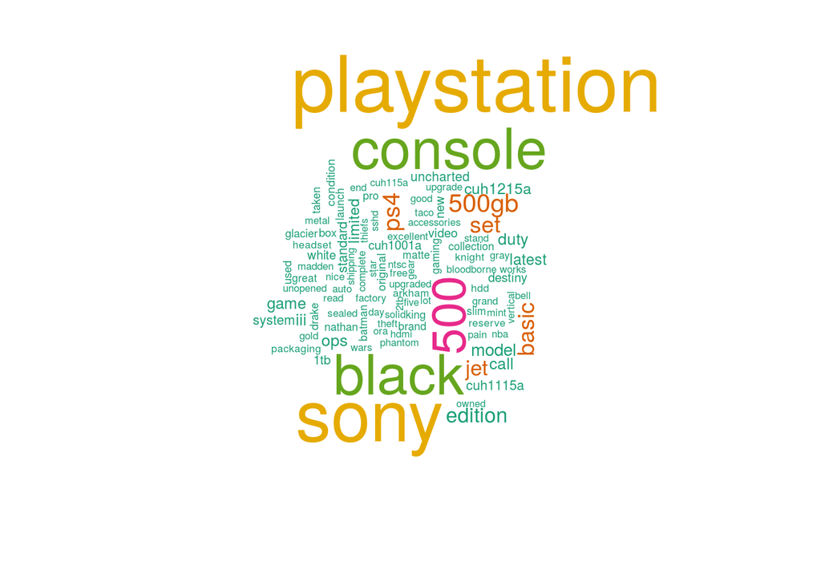

```r
set.seed(142)
wordcloud(names(freq),freq,max.words=100,rot.per=.2,colors=brewer.pal(6,"Dark2"))
```

## Cleaning the Title

Here we add the split up title data frame to the full dataset to add it as a feature for prediction.

```r
dtmsDF = as.data.frame(as.matrix(dtms))
dtmsDF$X_id = fullDataset$X_id
fullDataset = merge(fullDataset,dtmsDF, by = "X_id")
fullDataset$title = NULL
names(fullDataset) = make.names(names(fullDataset))
```

## Machine Learning

Here I’m training multiple different machine learning algorithms in order to compare them against one another using RMSE on the test set.

### Cross-Validation of the Full Dataset

Here I’m splitting the data into a test and train set for cross-validation, as well as a few small preprocessing steps.

```r
library(randomForest)
library(caret)
library(rpart)
library(mlbench)

set.seed(415)
smp_size <- floor(0.75 * nrow(fullDataset))
train_indices = sample(seq_len(nrow(fullDataset)),size=smp_size)
trainingData = fullDataset[train_indices,]
testData     = fullDataset[-train_indices,]

make.names(levels(trainingData))
```

```
## character(0)
```

### NeuralNet

Here I’m training a neural net, turning over the size variables as well as decay.

```r
library(nnet)
modelNN = train(trainingData[,c(2,5,10,11,14,15,17,36),],trainingData$sellingPrice, method='nnet', linout=TRUE, trace = FALSE, maxit=1000,
                #Grid of tuning parameters to try:
                tuneGrid=expand.grid(.size=c(1,5,10),.decay=c(0,0.001,0.1)))
```

### Linear Regression

Here I’m training a linear regression model.

```r
modelGLM =  glm(trainingData$sellingPrice ~ trainingData$currentPrice +
                        trainingData$totalPrice +
                        trainingData$bidCount +
                        trainingData$listingType +
                        trainingData$conditionId)
modelLM  = lm(trainingData$sellingPrice ~ trainingData$currentPrice +
                        trainingData$totalPrice +
                        trainingData$bidCount +
                        trainingData$listingType +
                        trainingData$conditionId +
                        trainingData$dayOfWeek +
                        trainingData$edition)
```

### GLMNet

```r
library(glmnet)
library(Matrix)
GLMNetctrl = trainControl(method="repeatedcv", number=10, repeats= 3,search="grid")
tunegrid = expand.grid(.alpha=seq(0,1,.1),.lambda=c(0:15))
modelGLMNet = train(sellingPrice ~
                        currentPrice +
                        totalPrice +
                        bidCount +
                        listingType +
                        conditionId +
                        dayOfWeek +
                        edition,data=trainingData, method="glmnet",trControl=GLMNetctrl, tuneGrid=tunegrid)
```

### SVM

```r
library(kernlab)
SVMctrl = trainControl(method="repeatedcv",number=10,repeats=3)

modelSVM = train(sellingPrice ~
                        currentPrice +
                        totalPrice +
                        bidCount +
                        listingType +
                        conditionId +
                        dayOfWeek +
                        edition,data=trainingData, method="svmLinear",trControl=SVMctrl)
```

```r
library(kernlab)
SVMctrlR = trainControl(method="repeatedcv",number=10,repeats=3)
modelSVMR = train(sellingPrice ~
                        currentPrice +
                        totalPrice +
                        bidCount +
                        listingType +
                        conditionId +
                        dayOfWeek +
                        edition,data=trainingData, method="svmRadial",trControl=SVMctrl)
```

## Price Prediction

We now have a price prediction! The items the algorithm predicts to have a higher price than they sold for are items I will target for purchasing, items lower or below a profit threshold will be ignored.

The predictions are made, and RMSE against the test set is taken in order to select the most accurate machine learning algorithms.

```r
options(width = 1000)
##RANDOM FOREST PREDICTION
modelRF
```

```
## Random Forest
##
## 822 samples
##   7 predictors
##
## No pre-processing
## Resampling: Cross-Validated (10 fold, repeated 3 times)
## Summary of sample sizes: 739, 739, 740, 739, 741, 741, ...
## Resampling results across tuning parameters:
##
##   mtry  RMSE      Rsquared
##    1    39.27841  0.6280630
##    2    32.77796  0.6532402
##    3    31.89493  0.6551324
##    4    31.87098  0.6543588
##    5    32.03830  0.6511541
##    6    32.22236  0.6478545
##    7    32.35928  0.6452307
##    8    32.44278  0.6435712
##    9    32.49475  0.6428315
##   10    32.69318  0.6391877
##   11    32.75517  0.6377128
##   12    32.87788  0.6356592
##   13    32.96935  0.6339659
##   14    33.05244  0.6324629
##   15    33.05315  0.6325832
##
## RMSE was used to select the optimal model using  the smallest value.
## The final value used for the model was mtry = 4.
```

```r
predictRF <- predict(modelRF, newdata = testData)
predictRF_2 <- predict(modelRF_2, newdata = testData)


# varImp(modelRF_2$finalModel)
# varImp(modelRF$finalModel)
#
# varImpPlot(modelRF_2$finalModel)
# varImpPlot(modelRF$finalModel)
```

### RMSE

Here are the RMSE for each algorithm

```r
RFrmse <- sqrt(mean((predictRF - testData$sellingPrice)^2))
RFrmse
```

```
## [1] 30.91988
```

```r
RFrmse_2 <- sqrt(mean((predictRF_2 - testData$sellingPrice)^2))
RFrmse_2
```

```
## [1] 31.45724
```

```r
##GLM PREDICTION
# summary(modelGLM)
GLMpredict = predict(modelGLM,newdata = testData)
GLMrmse <- sqrt(mean((GLMpredict - testData$sellingPrice)^2))
GLMrmse
```

```
## [1] 67.67035
```

```r
##LM PREDICTION
# summary(modelLM)
LMpredict = predict(modelLM,newdata = testData)
LMrmse <- sqrt(mean((LMpredict - testData$sellingPrice)^2))
LMrmse
```

```
## [1] 68.16249
```

```r
##GLMNet PREDICTION
GLMNetpredict <- predict(modelGLMNet, newdata = testData)
GLMNetrmse <- sqrt(mean((GLMNetpredict - testData$sellingPrice)^2))
GLMNetrmse
```

```
## [1] 31.11125
```

```r
##NN PREDICTION
NNpredict <- predict(modelNN, newdata = testData)
NNrmse <- sqrt(mean((NNpredict - testData$sellingPrice)^2))
NNrmse
```

```
## [1] 32.36508
```

```r
##SVM PREDICTION
SVMpredict <- predict(modelSVM, newdata = testData)
SVMrmse <- sqrt(mean((SVMpredict - testData$sellingPrice)^2))
SVMrmse
```

```
## [1] 30.26452
```

```r
##SVM3 PREDICTION
SVMpredict3 <- predict(modelSVM3, newdata = testData)
SVMrmse3 <- sqrt(mean((SVMpredict3 - testData$sellingPrice)^2))
SVMrmse3
```

```
## [1] 37.36498
```

```r
##SVMRADIAL PREDICTION
SVMpredictR <- predict(modelSVMR, newdata = testData)
SVMrmseR <- sqrt(mean((SVMpredictR - testData$sellingPrice)^2))
SVMrmseR
```

```
## [1] 34.49452
```

Here we observe that the first Random Forest model as well as the first SVM model perform the best on the test set. These will be used to detect items for sale below our predicted price.

## Output

Here we plot the outcome against the predictions made by the Random Forest and SVM algorithms, as well as the average of these two predictions. It is then sorted by the most profitable items.

```r
SVMprofit = round(SVMpredict-testData$sellingPrice,2)
RFprofit = round(predictRF-testData$sellingPrice,2)
printOutRF = data.frame(testData$X_id,testData$sellingPrice,RFprofit,SVMprofit, rowMeans(cbind(SVMprofit,RFprofit)))
colnames(printOutRF) = c("itemId", "priceSold","predictedProfit_RF","predictedProfit_SVM", "avgPredictedProfit")
printOutRF = printOutRF[order(printOutRF$avgPredictedProfit,decreasing=TRUE),]
printOutRF
```

```
##            itemId priceSold predictedProfit_RF predictedProfit_SVM avgPredictedProfit
## 988  332000007489    158.29             111.25              114.54            112.895
## 975  322326493360    127.50             109.22               53.72             81.470
## 401  192007168188    255.00              85.87               65.64             75.755
## 655  262613806540    230.00              66.14               46.33             56.235
## 357  182333187247    149.49              54.55               45.32             49.935
## 361  182338982582    242.50              56.56               42.96             49.760
## 810  282247067075    223.00              53.15               44.10             48.625
## 84   122211776615    225.00              57.72               36.18             46.950
## 716  262718314570    175.00              49.52               38.88             44.200
## 180  152292945987    208.00              46.48               40.42             43.450
## 514  222305963744    180.00              42.22               43.84             43.030
## 63   122198104186    162.50              57.06               27.84             42.450
## 362  182339003245    215.00              44.12               40.27             42.195
## 375  182344309342    226.00              44.62               38.41             41.515
```

[output cut: 261 more lines]

## Overview

Typically you’d want to minimize error, but in this case, I’m really trying to exploit the error of a machine learning algorithm in a sense. I want my algorithm to be “smarter” than the data, the cases where it’s “incorrect” (really we’re saying the algorithm is correct and the market is not correct) in a certain direction will be cases I expect to see profit. This was initially difficult for me to wrap my head around when looking at the outputs from the various algorithms.